# Reproduce the applied example in A translational framework of genoproteomic studies for cardiovascular drug discovery

YANG, Zhao

星期三, 四月 10, 2024, 17:29

This document contains materials required for reproducing the results of the applied example in **A translational framework of genoproteomic studies for cardiovascular drug discovery**. More details of the translational framework, please refer to our **manuscript**.

### 1. Prerequests

#### 1.1 Packages

To run the codes for the applied example, one have to install pkg in R from GitHub, as follows,

```r
# devtools::install_github("yangzhao98/drugTargetScreen",force=TRUE)
library(drugTargetScreen)
path.res <- getwd()
```

Moreover, one may have to install [PLINK](https://www.cog-genomics.org/plink2/) for LD clumping, with ancestry-specific 1000 Genome Project as the reference, available at [MRCIEU](http://fileserve.mrcieu.ac.uk/ld/1kg.v3.tgz).

#### 1.2 Data sources

- GWAS summary statistics for LDL-C are available at the [Global Lipids Genetics Consortium](https://csg.sph.umich.edu/willer/public/glgc-lipids2021/)
- GWAS summary statistics for CAD are available at the [CARDIoGRAMplusC4D Consortium](http://www.cardiogramplusc4d.org/data-downloads/)
- GWAS summary statistics for 78 clinical endpoints and LDL-C in the UK Biobank are available at [Neale lab](https://www.nealelab.is/uk-biobank)
- Summary statistics of *cis-* and *trans-*eQTLs are available at the [eQTLGen phase 1](https://www.eqtlgen.org/phase1.html)

### 2. Reproduce the results of the applied example

This example screens and verifies the low-density lipoprotein cholesterol (LDL-C)-lowering drug targets of CETP inhibitors, statins (HMGCR), ezetimibe (NPC1L1), and PCSK9 inhibitors, which have been considered positive control examples in validating lipid-related therapeutics targets of coronary artery disease under the proposed translational framework.

#### 2.1 The translational framework for cardiovascular drug discovery

Briefly, this framework consists of four main stages,

1. Causal biomarkers screen
2. Drug-targeting protein discovery and verification
   - Elucidation of possible heterogeneous genetic effects oriented by polygenic IVs across the genome for the biomarker, utilizing methodologies such as [Genome-wide mR Analysis under Pervasive PLEitropy (GRAPPLE)](https://github.com/jingshuw/GRAPPLE) and [MR-PATH](https://github.com/danieliong/MRPATH)
   - Exploration of the putative protein-disease association using *cis*-acting pQTL as IVs, supplemented by the inclusion of *trans*-acting variants and *cis*-position, *trans*-acting variants, as appropriate
   - Verification of putative drug-targeting proteins by examining whether the *cis*-acting variants are shared with the same causal variants as the upstream regulators or downstream intermediates, utilizing [colocalization](https://github.com/stephenslab/susieR) based on gene expression database or conducting cell and animal experiments.
3. Drug target relevant side effects exploration
4. Therapeutic efficacy and safety emulation

#### 2.2 Implementations

```r
## preparation
source(paste(path.res,"/0_precondition.R",sep=""))
source(paste(path.res,"/utilities.R",sep=""))

## codes for stage 1. Causal biomarkers screen
source(paste(path.res,"/1_cause_biomarkers_screen.R",sep=""))

## codes for stage 2. Drug-targeting protein discovery and verification
source(paste(path.res,"/2_discovery_verification.R",sep=""))

## codes for stage 3. Drug target relevant side effects exploration
source(paste(path.res,"/3_side_effects.R",sep=""))

## codes for Stage 4. Therapeutic efficacy and safety emulation
source(paste(path.res,"/4_target_trial_emulation.R",sep=""))
```

#### 2.3 Results

```r
load(paste(
  path.res,"/",
  grep(".RData",list.files(path.res),value=TRUE),
  sep=""))
```

##### 2.3.1 Results in Stage 1

Scatter plot of genetic effects on LDL-C and CAD using all SNPs at genome-wide significance with LD clumping at $r^2<0.3$ and those within either CETP, HMGCR, NPC1L1, and PCSK9 locus

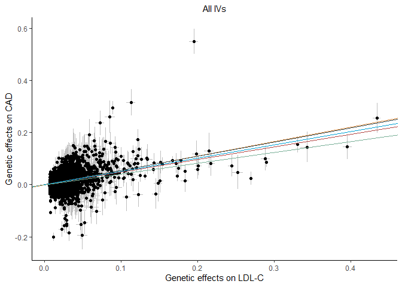

```r
plt.woCor
```

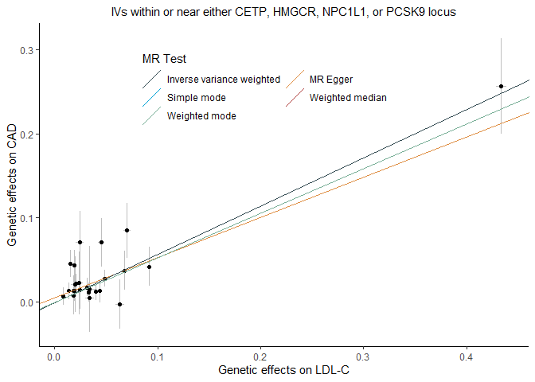

```r
plt.4Gene
```

##### 2.3.2 Results in Stage 2

- Pleiotropic effects detected using profile likelihood under the GRAPPLE framework

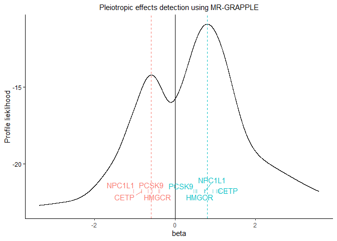

```r
plt.GRAPPLE.profile
```

- Forest plot of MR estimates obtained from MR based on various kinds of IVs

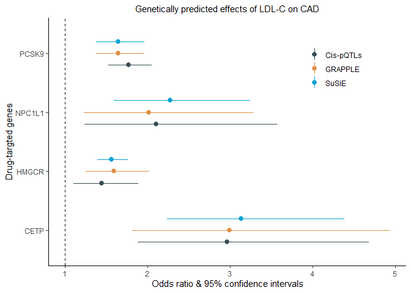

```r
plt.Forest
```

- Colocalization of LDL-C, eQTL, and CAD

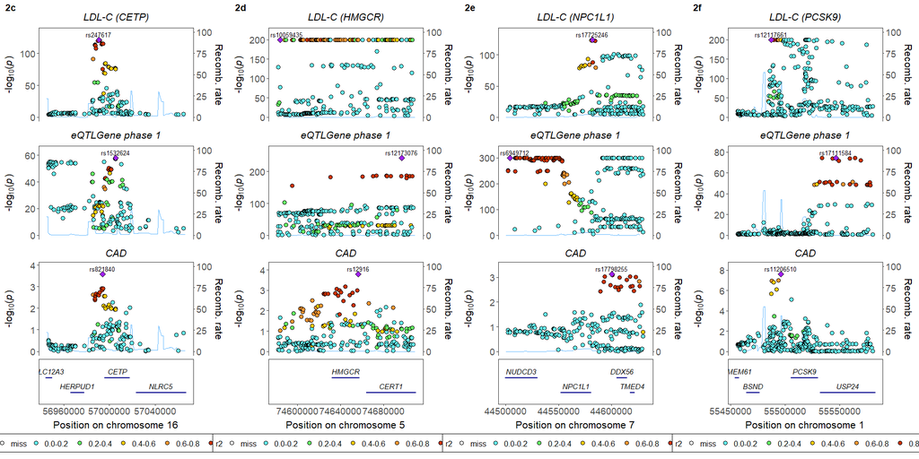

```r
plt.Step2
```

##### 2.3.3 Results in Stage 3

Phenome-wide MR estimates of genetically mimicked effects of CETP inhibitors, statins (HMGCR), ezetimibe (NPC1L1), and PCSK9 inhibitors on 78 clinical endpoints with ICD-10 diagnoses in the UK Biobank

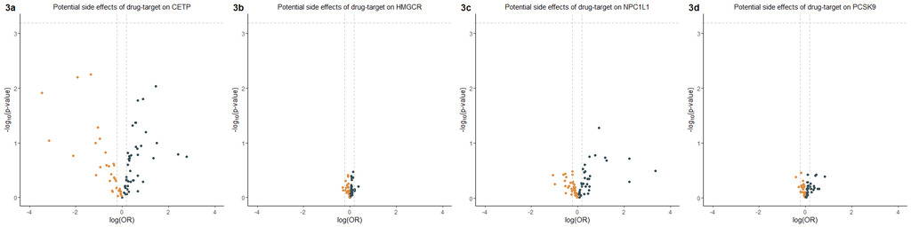

```r
plt.Step3
```

##### 2.3.4 Results in Stage 4

The protective effects of hypothetical intervention in LDL-C-lowering on ASCVD, CVD, and all-cause mortality

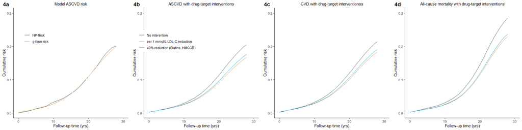

```r
plt.Step4
```